# R Notebook for Module 9 Lab: Categorical Predictors and Nonlinear OLS

Neil Yetz & Gemma Wallace

# Load Libraries

```r
library(tidyverse)
library(olsrr)
library(psych)
```

# Read in dataset

```r
slp <- read_csv("slpdata.csv")
```

# Describe variables

```r
describe(slp)
```

|  | vars | n | mean | sd | median | trimmed | mad | min | max | range | skew | kurtosis | se |
| --- | --- | --- | --- | --- | --- | --- | --- | --- | --- | --- | --- | --- | --- |
| cond | 1 | 600 | 2.00 | 0.82 | 2.00 | 2.00 | 1.48 | 1.00 | 3.00 | 2.00 | 0.00 | -1.50 | 0.03 |
| prior | 2 | 600 | 0.72 | 0.45 | 1.00 | 0.78 | 0.00 | 0.00 | 1.00 | 1.00 | -1.00 | -1.01 | 0.02 |
| age | 3 | 600 | 44.94 | 12.87 | 45.20 | 45.12 | 16.46 | 20.00 | 67.80 | 47.80 | -0.10 | -1.14 | 0.53 |
| anxiety | 4 | 600 | 3.88 | 0.90 | 3.86 | 3.89 | 0.93 | 1.05 | 6.84 | 5.79 | -0.07 | -0.06 | 0.04 |
| hygiene | 5 | 600 | 5.99 | 1.57 | 6.05 | 6.04 | 1.57 | 1.68 | 9.74 | 8.06 | -0.23 | -0.29 | 0.06 |
| support | 6 | 600 | 3.04 | 0.68 | 2.96 | 3.02 | 0.73 | 1.09 | 4.91 | 3.82 | 0.21 | -0.51 | 0.03 |
| sleep | 7 | 600 | 68.88 | 12.14 | 69.00 | 69.09 | 11.86 | 34.00 | 99.00 | 65.00 | -0.16 | -0.17 | 0.50 |
| lifesat | 8 | 600 | 4.06 | 0.92 | 4.05 | 4.04 | 0.96 | 1.68 | 6.61 | 4.93 | 0.13 | -0.23 | 0.04 |
| sex | 9 | 600 | 1.41 | 0.49 | 1.00 | 1.39 | 0.00 | 1.00 | 2.00 | 1.00 | 0.36 | -1.87 | 0.02 |
| id | 10 | 600 | 300.50 | 173.35 | 300.50 | 300.50 | 222.39 | 1.00 | 600.00 | 599.00 | 0.00 | -1.21 | 7.08 |

```r
NA
```

categorical vars = cond, prior, & sex

# Part 1: Using dummy coding, use treatment condition, sex, and their interaction to predict sleep hygiene.

## Specify dummy codes for categorical predictors

```r
#sex & condition
slp <- mutate(slp,
              sex = ifelse(sex == 1, 0, 1),
              sex.f = factor(sex, levels = c(0,1), labels = c("male", "female")))

slp <- mutate(slp,
              cond2 = ifelse(cond == 2, 1, 0),
              cond3 = ifelse(cond == 3, 1, 0),
              cond.f = factor(cond, levels = c(1,2,3), labels = c("self help", "group-based", "group + partner")))
```

## Run model without interaction first

```r
m1_no_interaction <- lm(hygiene ~ cond2 + cond3, data = slp)
ols_regress(m1_no_interaction)
```

```
                        Model Summary
--------------------------------------------------------------
R                       0.630       RMSE                1.224
R-Squared               0.397       Coef. Var          20.418
Adj. R-Squared          0.395       MSE                 1.498
Pred R-Squared          0.391       MAE                 0.973
--------------------------------------------------------------
 RMSE: Root Mean Square Error
 MSE: Mean Square Error
 MAE: Mean Absolute Error

                                ANOVA
----------------------------------------------------------------------
                Sum of
               Squares         DF    Mean Square       F         Sig.
----------------------------------------------------------------------
Regression     589.467          2        294.733    196.774    0.0000
Residual       894.205        597          1.498
Total         1483.671        599
----------------------------------------------------------------------

                                 Parameter Estimates
-------------------------------------------------------------------------------------
      model     Beta    Std. Error    Std. Beta      t        Sig     lower    upper
-------------------------------------------------------------------------------------
(Intercept)    4.660         0.087                 53.853    0.000    4.490    4.830
      cond2    1.627         0.122        0.488    13.293    0.000    1.386    1.867
      cond3    2.374         0.122        0.712    19.399    0.000    2.134    2.615
-------------------------------------------------------------------------------------
```

Interpretation of dummy coded model:

Intercept: The predicted sleep hygiene score when all x variables are zero, so participants in Condition 1.

cond2: the predicted difference in sleep hygiene score between particiants in condition 2 compared to condition 1.

cond3: the predicted difference in sleep hygiene score between particiants in condition 3 compared to condition 1.

## Run model with interaction

```r
m1 <- lm(hygiene ~ sex.f + cond2 + cond3 + sex.f*cond2 + sex.f*cond3, data = slp)
ols_regress(m1)
```

```
                        Model Summary
--------------------------------------------------------------
R                       0.771       RMSE                1.007
R-Squared               0.594       Coef. Var          16.801
Adj. R-Squared          0.591       MSE                 1.014
Pred R-Squared          0.585       MAE                 0.799
--------------------------------------------------------------
 RMSE: Root Mean Square Error
 MSE: Mean Square Error
 MAE: Mean Absolute Error

                                ANOVA
----------------------------------------------------------------------
                Sum of
               Squares         DF    Mean Square       F         Sig.
----------------------------------------------------------------------
Regression     881.213          5        176.243    173.768    0.0000
Residual       602.459        594          1.014
Total         1483.671        599
----------------------------------------------------------------------

                                     Parameter Estimates
----------------------------------------------------------------------------------------------
            model      Beta    Std. Error    Std. Beta      t        Sig      lower     upper
----------------------------------------------------------------------------------------------
      (Intercept)     3.751         0.098                 38.346    0.000     3.559     3.943
      sex.ffemale     1.935         0.143        0.418    13.562    0.000     1.655     2.215
            cond2     2.084         0.132        0.625    15.813    0.000     1.825     2.343
            cond3     2.962         0.135        0.888    21.933    0.000     2.697     3.227
sex.ffemale:cond2    -0.643         0.207       -0.119    -3.113    0.002    -1.048    -0.237
sex.ffemale:cond3    -1.160         0.203       -0.223    -5.710    0.000    -1.558    -0.761
----------------------------------------------------------------------------------------------
```

Interpretation of dummy coding model:

Intercept: The predicted sleep hygiene score when all x variables are zero, so males in Condition 1.

female: This variable is involved in an interaction, so it’s a simple slope. Specifically, it is the effect of female when both cond2 = 0 and cond3 = 0, so people in Condition 1. Therefore, it is the predicted difference in sleep hygiene between females and males in Condition 1. The slope is positive, meaning that females in Condition 1 tend to have better sleep hygiene than males in Condition 1. This is a sta-tistically significant difference (p-value is less than alpha).

cond2: This variable is involved in an interaction, so it is a simple slope. It is the effect of being in Condition 2 (compared to Condition 1) when female = 0, so among males. It is the predicted difference in sleep hygiene for males in Condition 2 compared to males in Condition 1. This is a statistically significant difference (p-value is less than alpha).

cond3: This variable is involved in an interaction, so it is a simple slope. It is the effect of being in Condition 3 (compared to Condition 1) when female = 0, so among males. It is the predicted difference in sleep hygiene for males in Condition 3 compared to males in Condition 1. This is a statistically significant difference (p-value is less than alpha).

female:cond2: The predicted differential effect of being in Condition 2 compared to Condition 1 for females compared to males. This is a statistically significant difference (p-value is less than alpha). The coefficient for cond2 presents the effect (i.e., benefit) of being in Condition 2 (compared to 1) for males. To get the effect for females, we take the effect for males (2.084) and add the female:cond2 interaction term (-.643). Therefore, the effect (i.e., benefit) of being in Condition 2 (compared to Condition 1) for females is 1.441.

female:cond3: The predicted differential effect of being in Condition 3 compared to Condition 1 for females compared to males. This is a statistically significant difference (p-value is less than alpha). The coefficient for cond3 presents the effect (i.e., benefit) of being in Condition 3 (compared to 1) for males. To get the effect for females, we take the effect for males (2.962) and add the female:cond3 interaction term (-1.160). Therefore, the effect (i.e., benefit) of being in Condition 3 (compared to Condition 1) for females is 1.802.

# Part 2: Redo this analysis using effect coding for treatment condition

## Specificy effect coding for categotical variables

“With this coding structure the same process is completed as that for dummy coding except the last group receives a −1 on all contrasts, thus only k −1 contrasts are used in this coding type (Wendorf, 2004).” (from Davis, 2010)

```r
slp <- mutate(slp,

              cond2 = ifelse(cond == 2, 1, 0),
              cond3 = ifelse(cond == 3, 1, 0),

              cond2 = ifelse(cond == 1, (-1), cond2),
              cond3 = ifelse(cond == 1, (-1), cond3),

              cond.f = factor(cond, levels = c(1,2,3), labels = c("self help", "group-based", "group + partner"))) #need this label specifier here?
```

## Run model without interaction first

```r
m2_no_interaction <- lm(hygiene ~ cond2 + cond3, data = slp)
ols_regress(m2_no_interaction)
```

```
                        Model Summary
--------------------------------------------------------------
R                       0.630       RMSE                1.224
R-Squared               0.397       Coef. Var          20.418
Adj. R-Squared          0.395       MSE                 1.498
Pred R-Squared          0.391       MAE                 0.973
--------------------------------------------------------------
 RMSE: Root Mean Square Error
 MSE: Mean Square Error
 MAE: Mean Absolute Error

                                ANOVA
----------------------------------------------------------------------
                Sum of
               Squares         DF    Mean Square       F         Sig.
----------------------------------------------------------------------
Regression     589.467          2        294.733    196.774    0.0000
Residual       894.205        597          1.498
Total         1483.671        599
----------------------------------------------------------------------

                                 Parameter Estimates
--------------------------------------------------------------------------------------
      model     Beta    Std. Error    Std. Beta       t        Sig     lower    upper
--------------------------------------------------------------------------------------
(Intercept)    5.994         0.050                 119.969    0.000    5.896    6.092
      cond2    0.293         0.071        0.152      4.149    0.000    0.154    0.432
      cond3    1.041         0.071        0.540     14.726    0.000    0.902    1.179
--------------------------------------------------------------------------------------
```

Interpretation of effect coding model:

Effects coding allows us to examine mean differences between two groups. In effects coding, the slope estimates are simply the difference between the mean of the group coded as 1 and the grand mean of all the groups.

**check math** Intercept: In effect coding, the intercept is the grand mean of sleep hygiene across all the three treatment groups

cond2: the predicted difference in sleep hygiene score between particiants in condition 2 compared to the mean of all three treatment conditions.

cond3: the predicted difference in sleep hygiene score between particiants in condition 3 compared to the mean of all three treatment conditions.

## Run model with interaction

```r
m2 <- lm(hygiene ~ sex.f + cond2 + cond3 + sex.f*cond2 + sex.f*cond3, data = slp)
ols_regress(m2)
```

```
                        Model Summary
--------------------------------------------------------------
R                       0.771       RMSE                1.007
R-Squared               0.594       Coef. Var          16.801
Adj. R-Squared          0.591       MSE                 1.014
Pred R-Squared          0.585       MAE                 0.799
--------------------------------------------------------------
 RMSE: Root Mean Square Error
 MSE: Mean Square Error
 MAE: Mean Absolute Error

                                ANOVA
----------------------------------------------------------------------
                Sum of
               Squares         DF    Mean Square       F         Sig.
----------------------------------------------------------------------
Regression     881.213          5        176.243    173.768    0.0000
Residual       602.459        594          1.014
Total         1483.671        599
----------------------------------------------------------------------

                                      Parameter Estimates
-----------------------------------------------------------------------------------------------
            model      Beta    Std. Error    Std. Beta       t        Sig      lower     upper
-----------------------------------------------------------------------------------------------
      (Intercept)     5.433         0.054                 101.005    0.000     5.327     5.539
      sex.ffemale     1.334         0.084        0.418     15.880    0.000     1.169     1.499
            cond2     0.402         0.074        0.209      5.425    0.000     0.257     0.548
            cond3     1.280         0.076        0.665     16.831    0.000     1.131     1.429
sex.ffemale:cond2    -0.042         0.120       -0.014     -0.349    0.727    -0.278     0.194
sex.ffemale:cond3    -0.559         0.118       -0.193     -4.719    0.000    -0.791    -0.326
-----------------------------------------------------------------------------------------------
```

Interpretation of effect coding model:

Effects coding allows us to examine mean differences between two groups. In effects coding, the slope estimates are simply the difference between the mean of the group coded as 1 and the grand mean of all the groups.

**ummmmmmmm, wtf** female: This variable is involved in an interaction, so it’s a simple slope. It is the predicted difference in sleep hygiene between females and males in all of the conditions?

female:cond2: The predicted differential effect of being in Condition 2 compared to the grand mean for females compared to males. This is not a statistically significant difference (p-value is greater than alpha). The coefficient for cond2 presents the effect (i.e., benefit) of being in Condition 2 (compared to average) for males. To get the effect for females, we take the effect for males (0.402) and add the female:cond2 interaction term (-.042). Therefore, the effect (i.e., benefit) of being in Condition 2 (compared to average for females is 0.36.

female:cond3: The predicted differential effect of being in Condition 3 compared to average for females compared to males. This is a statistically significant difference (p-value is less than alpha). The coefficient for cond3 presents the effect (i.e., benefit) of being in Condition 3 (compared to average) for males. To get the effect for females, we take the effect for males (1.280) and add the female:cond3 interaction term (-.559). Therefore, the effect (i.e., benefit) of being in Condition 3 (compared to average) for females is 0.721.

The model suggests that males benefit more from cond3 compared to average, compared to how much females benefit from cond3 compared to average.

# Part 3: Orthogonal Polynomial Contrasts Practice

## Read in dataset

```r
cog <- read_csv("cogtest.csv")
```

Description of dataset: Researcheres were interested in the effect of time spent in practice on the performance of a visual discrimination task. Subjects were randomly assigned to different levels of practice, following which a test of visual discrimination is administered, and the number of correct responses is recorded for each subject. 40 subjects were randomly assigned to practice 0 minutes, 2 minutes, 4 minutes, 6 minutes, 8 minutes, 10 minutes, 12 minutes, or 14 minutes. There are two variables: practice = minutes spent practicing, this was assigned by the experimenter score = the number of correct answers on the test

## Filter the data to only include practive levels 0, 4, 8,and 12 minutes

```r
cog <- filter(cog, practice == 0 | practice == 4 | practice == 8 | practice == 12)
```

## Examine dataframe descriptives

```r
describe(cog)
```

|  | vars | n | mean | sd | median | trimmed | mad | min | max | range | skew | kurtosis | se |
| --- | --- | --- | --- | --- | --- | --- | --- | --- | --- | --- | --- | --- | --- |
| subject | 1 | 20 | 18.00 | 11.56 | 18.00 | 18.00 | 14.83 | 1.00 | 35.00 | 34.00 | 0.00 | -1.48 | 2.59 |
| practice | 2 | 20 | 6.00 | 4.59 | 6.00 | 6.00 | 5.93 | 0.00 | 12.00 | 12.00 | 0.00 | -1.52 | 1.03 |
| score | 3 | 20 | 15.14 | 8.48 | 17.95 | 15.71 | 7.43 | 1.06 | 25.54 | 24.48 | -0.55 | -1.30 | 1.90 |

## Plot the relationship between practice and score

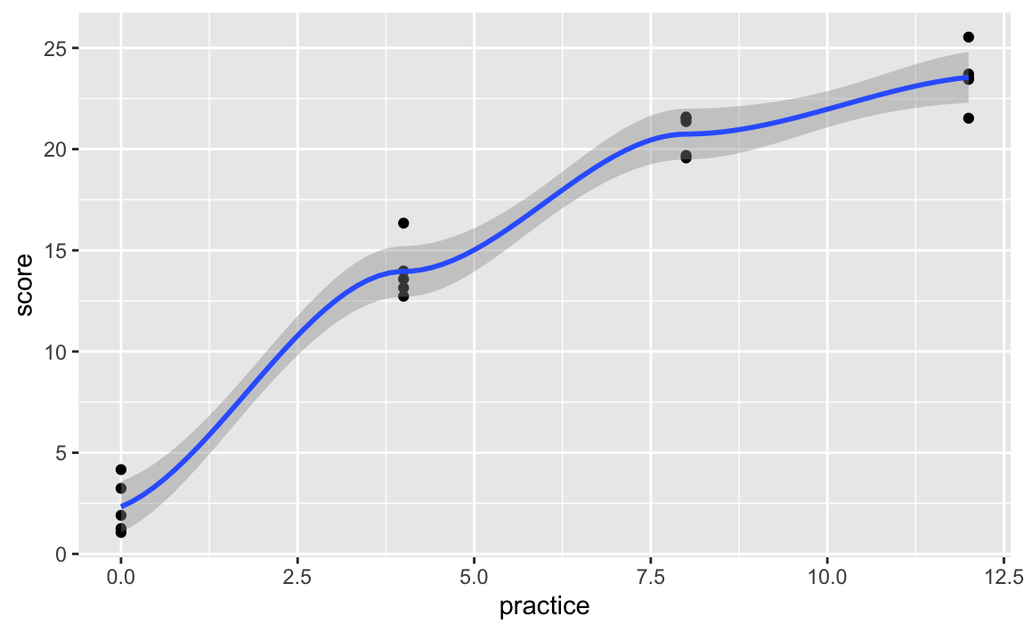

```r
ggplot(cog, aes(x = practice, y = score)) +
  geom_point() +
  geom_smooth(method = "loess")
```

What type of relationship do you think exists if any?

The slope appears to become less steep as length of assigned practice time increases. Since there may be a curve to the regression line, we should test for more than a linear effect. Since we have four levels of our categorical variable, we can test both a quadratic and cubic effect.

## Specify orthoganol polynomial contrast terms

```r
# these are common coefficients to specify for polynomial contrasts and these can be found online or in our demo slides. Note that we could use different contrasts for each type of relationship (e.g., linear, quadratic, etc.) if the categorical predictor had a different number of levels.
# Also note that we could not evaluate a cubic effect if we had <4 levels of the categorical predictor.

cog <- mutate(cog,

              linear = ifelse(practice == 0, -3, practice ),
              linear = ifelse(practice == 4, -1, linear   ),
              linear = ifelse(practice == 8,  1, linear   ),
              linear = ifelse(practice == 12, 3, linear   ),

              quadratic = ifelse(practice == 0,  1, practice ),
              quadratic = ifelse(practice == 4, -1, quadratic),
              quadratic = ifelse(practice == 8, -1, quadratic),
              quadratic = ifelse(practice == 12, 1, quadratic),

              cubic = ifelse(practice == 0, -1, practice),
              cubic = ifelse(practice == 4,  3, cubic   ),
              cubic = ifelse(practice == 8, -3, cubic   ),
              cubic = ifelse(practice == 12, 1, cubic   )
              )
```

## Run model with just the linear effect

```r
m3 <- lm(score ~ linear, data = cog)
ols_regress(m3)
```

```
                        Model Summary
--------------------------------------------------------------
R                       0.953       RMSE                2.635
R-Squared               0.909       Coef. Var          17.400
Adj. R-Squared          0.903       MSE                 6.943
Pred R-Squared          0.886       MAE                 2.207
--------------------------------------------------------------
 RMSE: Root Mean Square Error
 MSE: Mean Square Error
 MAE: Mean Absolute Error

                                ANOVA
---------------------------------------------------------------------
                Sum of
               Squares        DF    Mean Square       F         Sig.
---------------------------------------------------------------------
Regression    1240.975         1       1240.975    178.727    0.0000
Residual       124.981        18          6.943
Total         1365.957        19
---------------------------------------------------------------------

                                  Parameter Estimates
----------------------------------------------------------------------------------------
      model      Beta    Std. Error    Std. Beta      t        Sig      lower     upper
----------------------------------------------------------------------------------------
(Intercept)    15.144         0.589                 25.702    0.000    13.906    16.382
     linear     3.523         0.264        0.953    13.369    0.000     2.969     4.076
----------------------------------------------------------------------------------------
```

These are the results of the liner model. The model testing the linear relationship between practice and score explained 90.9% of the variance in score, and the linear trend was statistically significant at p<0.001. This model fits the data pretty well, but since we observed a potential curved relationship when we plotted the data, there could be a better way to examine this relationship.

## Run model with the linear and quadratic effects

```r
m4 <- lm(score ~ linear + quadratic, data = cog)
ols_regress(m4)
```

```
                        Model Summary
-------------------------------------------------------------
R                       0.990       RMSE               1.274
R-Squared               0.980       Coef. Var          8.411
Adj. R-Squared          0.977       MSE                1.623
Pred R-Squared          0.972       MAE                0.944
-------------------------------------------------------------
 RMSE: Root Mean Square Error
 MSE: Mean Square Error
 MAE: Mean Absolute Error

                                ANOVA
---------------------------------------------------------------------
                Sum of
               Squares        DF    Mean Square       F         Sig.
---------------------------------------------------------------------
Regression    1338.373         2        669.187    412.425    0.0000
Residual        27.584        17          1.623
Total         1365.957        19
---------------------------------------------------------------------

                                  Parameter Estimates
----------------------------------------------------------------------------------------
      model      Beta    Std. Error    Std. Beta      t        Sig      lower     upper
----------------------------------------------------------------------------------------
(Intercept)    15.144         0.285                 53.168    0.000    14.543    15.745
     linear     3.523         0.127        0.953    27.655    0.000     3.254     3.791
  quadratic    -2.207         0.285       -0.267    -7.748    0.000    -2.808    -1.606
----------------------------------------------------------------------------------------
```

These are the results of the quadratic model. The model testing the linear relationship between practice and score explained 98.0% of the variance in score, which is 7.1% higher than the model that only tested the linear relationship. The quadratic term (named quadratic) is statistically significant, indicating that there is a substantial curve to the relationship between practice and score (i.e., it’s not linear). We need to maintain the quadratic term in the model.

## Run model with the linear, quadratic, and cubic effects

```r
m5 <- lm(score ~ linear + quadratic + cubic, data = cog)
ols_regress(m5)
```

```
                        Model Summary
-------------------------------------------------------------
R                       0.990       RMSE               1.309
R-Squared               0.980       Coef. Var          8.641
Adj. R-Squared          0.976       MSE                1.712
Pred R-Squared          0.969       MAE                0.954
-------------------------------------------------------------
 RMSE: Root Mean Square Error
 MSE: Mean Square Error
 MAE: Mean Absolute Error

                                ANOVA
---------------------------------------------------------------------
                Sum of
               Squares        DF    Mean Square       F         Sig.
---------------------------------------------------------------------
Regression    1338.559         3        446.186    260.572    0.0000
Residual        27.397        16          1.712
Total         1365.957        19
---------------------------------------------------------------------

                                  Parameter Estimates
----------------------------------------------------------------------------------------
      model      Beta    Std. Error    Std. Beta      t        Sig      lower     upper
----------------------------------------------------------------------------------------
(Intercept)    15.144         0.293                 51.755    0.000    14.524    15.764
     linear     3.523         0.131        0.953    26.921    0.000     3.245     3.800
  quadratic    -2.207         0.293       -0.267    -7.542    0.000    -2.827    -1.586
      cubic     0.043         0.131        0.012     0.330    0.746    -0.234     0.321
----------------------------------------------------------------------------------------
```

# Do it yourself activity

## Load packages

```r
library(tsibble)
library(tidycovid19)
```

```
Error in library(tidycovid19) : there is no package called ‘tidycovid19’
```

## Download data

## Recode lockdown variable

## Dummy code/factor income & lockdown

## Describe data

## Run dummy model

## Effect coding variables

## Run effect model

## Orthoganol polynomials